# Functional Diversity

Kate

December 16, 2018

## Functional Diversity Indices

**Functional diversity did not vary across the fire severity gradient.** Calculated values for each site are displayed for four indices of functional diversity: functional richness (FRic), functional divergence (FDiv), functional evenness (FEve), and functional dispersion (FDis). Means and standard deviations are shown for the three fire severity treatments: unburned (unb), low-moderate severity (mod), and high severity (high). Functional diversity indices were calculated using four ecologically relevant traits: diet, body size, activity time, and foraging mode. None of the differences in functional diversity between treatments were significant by ANOVA or Kruskal-Wallis ($\alpha$ = 0.5).

- Results were the same when two aspects of foraging mode (foraging height and degree of fossoriality) were split and equally weighted with the other three traits.

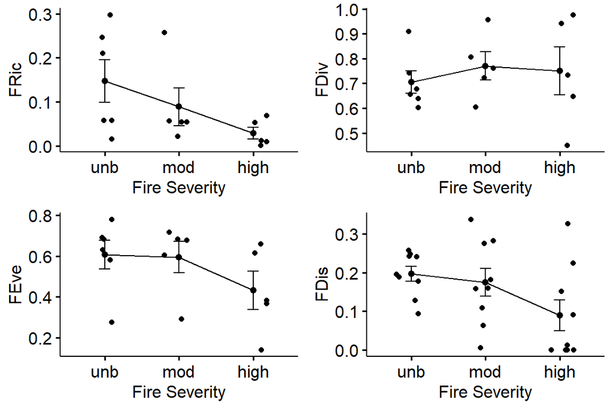

## Individual Components of Functional Diversity

### Biomass

**Increase of total biomass was not significant across the fire severity gradient.** Mean total site biomass increased with fire severity, but the differences between treatments was not significant(Kruskal-Wallis test, (chi square (2) = 1.7, p = 0.4, n = 9 for each). Biomass data from PanTHERIA.

- Results are the same using PHYLACINE body size data
- Outliers are sites that had a lot of ground squirrels

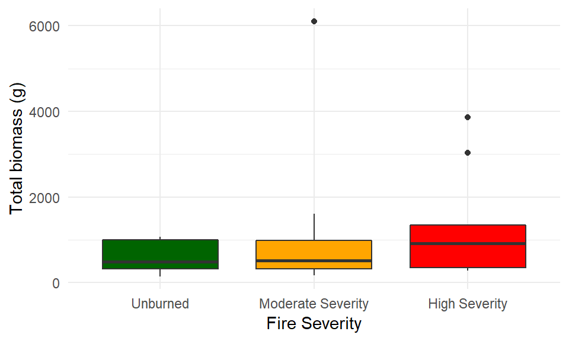

**Total biomass by species across the fire severity gradient.** Total biomass summed across sites for each severity, with the proportion contributed by each species. Increases in biomass were mainly driven by *P. maniculatus* and *O. beecheyi*.

- Strange that even though the mean biomass did not change between severities, the total biomass was much higher for mod and high severities (skewed by ground squirrel outliers)

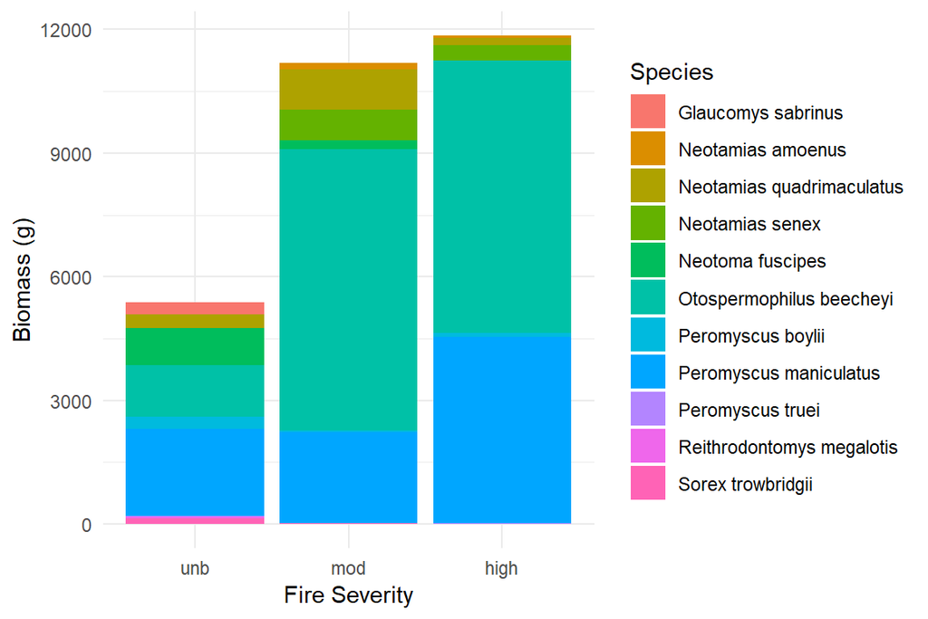

### Diet

**Abundance by feeding guild across the fire severity gradient.** All three treatments were dominated by generalist species.

- Categorical feeding guild (herbivore, omnivore, carnivore, insectivore) was not used in functional diversity calculations

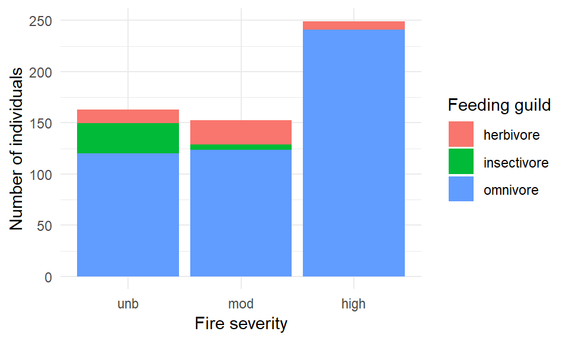

**The total biomass consuming each diet item did not vary across the fire severity gradient.** Differences between treatments the total biomass (in grams, summed across species) consuming each type of diet item were not significant (nonparametric one-way ANOVA-type multivariate test F(3.2, 38.5) = 1.1, p = 0.4).

- For each diet type (seeds, fruits, other vegetation, fungi, invertebrates, vertebrates), total contributing biomass was calculated for each site using the following formula: $\sum_{i=1}^n biomass_i * proportion_i$
  - *biomass<sub>i</sub>* = total biomass (g) for each species *i* at each site
  - *proportion<sub>i</sub>* = proportion (%) of each diet type consumed by each species *i* (determined from field guides and species accounts)
- I incorporated biomass in order to sum across species, since larger animals presumable eat more than smaller animals (and I was interested in the differences in total food resources consumed)

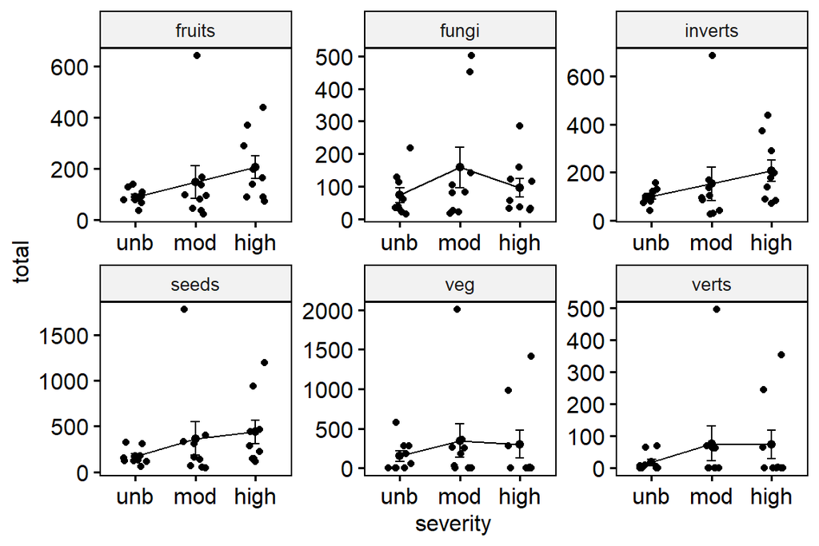

**Mosaic plot of community diet across fire severities.** Proportion of total biomass (summed across sites) that consumed each diet type by species for each severity. Although the overall proportion of biomass consuming each diet type remained consistent between treatments, the species contributing to the biomass consuming each diet type varied.

- Total biomass was calculated similarly to above, but summed by severity instead of species: for each severity, total contributing biomass was calculated for each diet type and species using the following formula: $\sum_{i=1}^n biomass_i * proportion$
  - *biomass<sub>i</sub>* = total biomass (g) for each species at each site *i*
  - *proportion* = proportion (%) of each diet type consumed by each species (determined from field guides and species accounts)

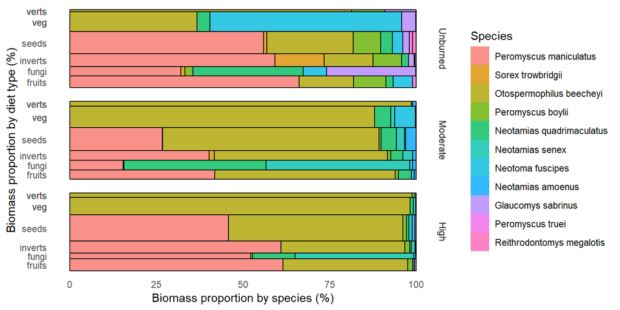

### Foraging mode

**Abundance by foraging height across fire severity treatments.** All severities were dominated by scansorial species.

- 0 = fully terrestrial
- 1 = scansorial - lower canopy
- 2 = scansorial - upper canopy
- 3 = fully arboreal (no representatives in our data)

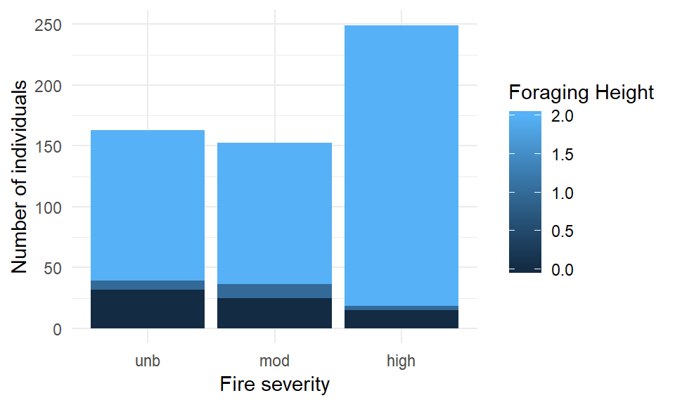

**Abundance by degree of fossoriality across fire severity treatments.** All severities were dominated by non-fossorial species.

- 0 = non-fossorial
- 1 = semi-fossorial (sometimes forages underground)
- 2 = semi-fossorial (sometimes forages and caches food underground)
- 3 = fully fossorial (no representatives in our data)

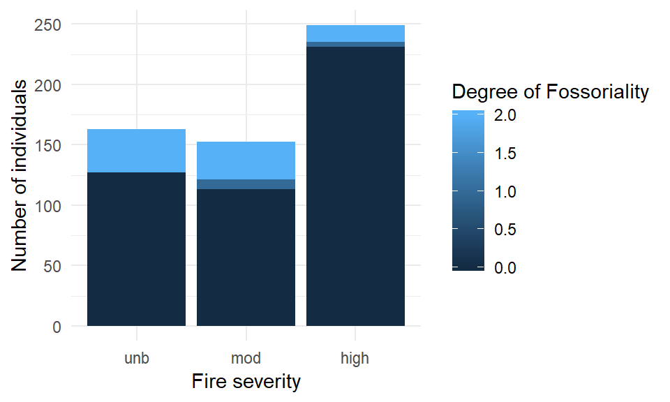

### Activity time

**Abundance by activity time across fire severity treatments.** All severities were dominated by nocturnal species.

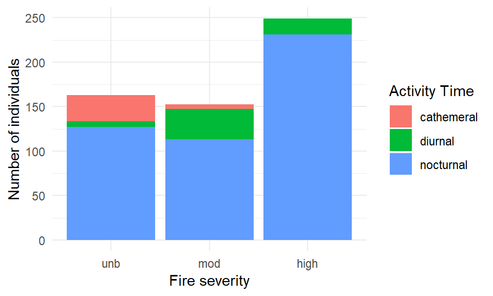